# **Proyek Machine Learning - Prediksi Harga Saham PT Astra Agro Lestari Tbk. (AALI.JK) Menggunakan Model Hybrid CNN-LSTM**

# Import library

```python
from google.colab import drive
drive.mount('/content/drive')
```

```python
!pip install keras-tuner -q
```

Pertama, dilakukan pengimporan semua pustaka Python yang diperlukan untuk proyek, termasuk pandas untuk manipulasi data, numpy untuk operasi numerik, matplotlib untuk visualisasi, scikit-learn untuk pra-pemrosesan dan metrik, serta TensorFlow/Keras untuk membangun dan melatih model deep learning.

```python
import pandas as pd
import numpy as np
import matplotlib.pyplot as plt
from sklearn.preprocessing import MinMaxScaler
from sklearn.metrics import mean_squared_error
import tensorflow
from tensorflow.keras.models import Sequential
from tensorflow.keras.layers import LSTM, Dense, Dropout
from tensorflow.keras.models import Sequential
from tensorflow.keras.layers import LSTM, Dense, Dropout, BatchNormalization
from tensorflow.keras.optimizers import Adam
import warnings
warnings.filterwarnings('ignore', category=UserWarning, module='keras.src.trainers.data_adapters.py_dataset_adapter')
from tensorflow.keras.callbacks import EarlyStopping
from tensorflow.keras.callbacks import ReduceLROnPlateau
from tensorflow.keras.callbacks import ModelCheckpoint

import random

from tensorflow.keras.models import Sequential
from tensorflow.keras.layers import Conv1D, MaxPooling1D, LSTM, Dense, Dropout, BatchNormalization
from tensorflow.keras.optimizers import Adam
from tensorflow.keras import regularizers

import numpy as np
import matplotlib.pyplot as plt

import keras_tuner as kt
from tensorflow.keras.models import Sequential
from tensorflow.keras.layers import Conv1D, MaxPooling1D, LSTM, Dense, Dropout, BatchNormalization
from tensorflow.keras.optimizers import Adam
from tensorflow.keras import regularizers
```

# Definisi Fungsi

Diatur seed untuk generator angka acak pada pustaka random, numpy, dan TensorFlow. Ini dilakukan untuk memastikan reproduktifitas hasil eksperimen.

```python
seed_value = 42
random.seed(seed_value)
np.random.seed(seed_value)
tensorflow.random.set_seed(seed_value)
```

Fungsi `plot_training_history` didefinisikan di sel ini untuk memvisualisasikan riwayat pelatihan model (misalnya, loss dan metrik lainnya) per epoch.

```python
def plot_training_history(history, metrics_to_plot=['loss']):
    """
    Memvisualisasikan riwayat pelatihan model (loss dan metrik lainnya).

    Args:
        history: Objek History yang dikembalikan oleh model.fit().
        metrics_to_plot (list): Daftar string nama metrik yang ingin diplot
                                (misal, ['loss', 'mae'] jika MAE juga dimonitor).
    """
    for metric_name in metrics_to_plot:
        plt.figure(figsize=(12, 6))

        # Plot metrik training
        if metric_name in history.history:
            plt.plot(history.history[metric_name], label=f'Training {metric_name.capitalize()}')
        else:
            print(f"Peringatan: Metrik '{metric_name}' tidak ditemukan dalam riwayat pelatihan.")
            continue  # Lanjut ke metrik berikutnya jika ada

        # Plot metrik validasi
        val_metric_name = f'val_{metric_name}'
        if val_metric_name in history.history:
            plt.plot(history.history[val_metric_name], label=f'Validation {metric_name.capitalize()}')

        plt.title(f'Model {metric_name.capitalize()} per Epoch')
        plt.ylabel(metric_name.capitalize())
        plt.xlabel('Epoch')
        plt.legend(loc='upper right')
        plt.grid(True)
        plt.show()
```

Fungsi `plot_training_predictions` didefinisikan untuk membuat prediksi pada data latih, melakukan inverse transform pada nilai prediksi dan aktual, kemudian memvisualisasikan perbandingannya dalam skala asli.

```python
def plot_training_predictions(model, train_generator, scaler, target_column_name='Harga'):
    """
    Membuat prediksi pada data latih, melakukan inverse transform,
    dan memvisualisasikan perbandingan nilai aktual vs. prediksi.

    Args:
        model: Model Keras yang sudah dilatih.
        train_generator: TimeseriesGenerator untuk data latih.
        scaler: Objek MinMaxScaler yang sudah di-fit.
        target_column_name (str): Nama kolom target untuk label sumbu Y pada plot.
    """
    # Membuat prediksi pada data latih
    predictions_train_scaled = model.predict(train_generator)

    # Mengumpulkan nilai aktual dari train generator
    y_train_scaled_from_generator_list = []
    for i in range(len(train_generator)):
        _, y_batch_train = train_generator[i]
        y_train_scaled_from_generator_list.extend(y_batch_train)
    y_train_scaled_from_generator = np.array(y_train_scaled_from_generator_list)

    # Sesuaikan panjang array agar konsisten
    num_train_predictions = len(predictions_train_scaled)
    y_train_scaled_from_generator = y_train_scaled_from_generator[:num_train_predictions]

    # Jika prediksi 3D, ambil timestep terakhir
    if predictions_train_scaled.ndim == 3:
        predictions_train_scaled = predictions_train_scaled[:, -1, :]

    # Pastikan array 2D untuk inverse_transform
    if predictions_train_scaled.ndim == 1:
        predictions_train_scaled = predictions_train_scaled.reshape(-1, 1)
    if y_train_scaled_from_generator.ndim == 1:
        y_train_scaled_from_generator = y_train_scaled_from_generator.reshape(-1, 1)

    # Inverse transform prediksi dan nilai aktual
    predictions_train_original_scale = scaler.inverse_transform(predictions_train_scaled)
    y_train_original_scale = scaler.inverse_transform(y_train_scaled_from_generator)

    # Visualisasi prediksi vs data aktual
    plt.figure(figsize=(14, 7))
    plt.plot(y_train_original_scale, label='Harga Aktual (Latih)', color='green', marker='.')
    plt.plot(predictions_train_original_scale, label='Prediksi Model (Latih)', color='orange', linestyle='--', marker='x')
    plt.title('Perbandingan Harga Aktual vs. Prediksi Model (Data Latih)')
    plt.xlabel('Indeks Waktu Data Latih')
    plt.ylabel(f'{target_column_name} Saham (Skala Asli)')
    plt.legend()
    plt.grid(True)
    plt.show()
```

Fungsi `plot_test_predictions` serupa dengan fungsi sebelumnya, namun digunakan untuk membuat, melakukan inverse transform, dan memvisualisasikan prediksi pada data uji dibandingkan dengan nilai aktualnya.

```python
def plot_test_predictions(model, test_generator, scaler, target_column_name='Harga'):
    """
    Membuat prediksi pada data uji, melakukan inverse transform,
    dan memvisualisasikan perbandingan nilai aktual vs. prediksi.

    Args:
        model: Model Keras yang sudah dilatih.
        test_generator: TimeseriesGenerator untuk data uji.
        scaler: Objek MinMaxScaler yang sudah di-fit.
        target_column_name (str): Nama kolom target untuk label sumbu Y pada plot.
    """
    # Membuat prediksi pada data uji
    predictions_scaled = model.predict(test_generator)

    # Mengumpulkan nilai aktual dari test_generator
    y_test_scaled_list = []
    for i in range(len(test_generator)):
        _, y_batch = test_generator[i]
        y_test_scaled_list.extend(y_batch)
    y_test_scaled = np.array(y_test_scaled_list)

    # Sesuaikan panjang array agar konsisten
    num_test_predictions = len(predictions_scaled)
    y_test_scaled = y_test_scaled[:num_test_predictions]

    # Jika prediksi 3D, ambil timestep terakhir
    if predictions_scaled.ndim == 3:
        predictions_scaled = predictions_scaled[:, -1, :]

    # Pastikan array 2D untuk inverse_transform
    if predictions_scaled.ndim == 1:
        predictions_scaled = predictions_scaled.reshape(-1, 1)
    if y_test_scaled.ndim == 1:
        y_test_scaled = y_test_scaled.reshape(-1, 1)

    # Inverse transform prediksi dan nilai aktual
    predictions_original_scale = scaler.inverse_transform(predictions_scaled)
    y_test_original_scale = scaler.inverse_transform(y_test_scaled)

    # Visualisasi
    plt.figure(figsize=(14, 7))
    plt.plot(y_test_original_scale, label='Harga Aktual (Uji)', color='blue', marker='.')
    plt.plot(predictions_original_scale, label='Prediksi Model (Uji)', color='red', linestyle='--', marker='x')
    plt.title('Perbandingan Harga Aktual vs. Prediksi Model (Data Uji)')
    plt.xlabel('Indeks Waktu Data Uji')
    plt.ylabel(f'{target_column_name} Saham (Skala Asli)')
    plt.legend()
    plt.grid(True)
    plt.show()
```

Import dataset

```python
file_path = '/content/drive/My Drive/Coding Camp/1. Proyek/5./df_with_date.csv'
df = pd.read_csv(file_path)
df
```

|  | Unnamed: 0 | Date | AALI.JK.Open | AALI.JK.High | AALI.JK.Low | AALI.JK.Close | AALI.JK.Volume | AALI.JK.Adjusted |
| --- | --- | --- | --- | --- | --- | --- | --- | --- |
| 0 | 1 | 2001-04-05 | 571.710632 | 571.710632 | 547.889343 | 547.889343 | 57721.0 | 238.185608 |
| 1 | 2 | 2001-04-06 | 547.889343 | 547.889343 | 547.889343 | 547.889343 | 83433.0 | 238.185608 |
| 2 | 3 | 2001-04-09 | 547.889343 | 547.889343 | 547.889343 | 547.889343 | 10494.0 | 238.185608 |
| 3 | 4 | 2001-04-10 | 547.889343 | 547.889343 | 547.889343 | 547.889343 | 352625.0 | 238.185608 |
| 4 | 5 | 2001-04-11 | 547.889343 | 547.889343 | 547.889343 | 547.889343 | 59295.0 | 238.185608 |
| ... | ... | ... | ... | ... | ... | ... | ... | ... |
| 5997 | 5998 | 2025-05-19 | 5950.000000 | 6050.000000 | 5950.000000 | 6050.000000 | 1113000.0 | 6050.000000 |
| 5998 | 5999 | 2025-05-20 | 6075.000000 | 6175.000000 | 6000.000000 | 6000.000000 | 843500.0 | 6000.000000 |
| 5999 | 6000 | 2025-05-21 | 6000.000000 | 6100.000000 | 6000.000000 | 6050.000000 | 498200.0 | 6050.000000 |
| 6000 | 6001 | 2025-05-22 | 6050.000000 | 6075.000000 | 6000.000000 | 6025.000000 | 276500.0 | 6025.000000 |
| 6001 | 6002 | 2025-05-23 | 6050.000000 | 6050.000000 | 6000.000000 | 6050.000000 | 94200.0 | 6050.000000 |

6002 rows × 8 columns

Dilakukan dua langkah pra-pemrosesan data: pertama, mengonversi kolom 'Date' menjadi format datetime, dan kedua, memilih hanya kolom 'Date' dan 'AALI.JK.Close' untuk analisis lebih lanjut.

```python
df['Date'] = pd.to_datetime(df['Date'])
df = df[['Date', 'AALI.JK.Close']]
df
```

|  | Date | AALI.JK.Close |
| --- | --- | --- |
| 0 | 2001-04-05 | 547.889343 |
| 1 | 2001-04-06 | 547.889343 |
| 2 | 2001-04-09 | 547.889343 |
| 3 | 2001-04-10 | 547.889343 |
| 4 | 2001-04-11 | 547.889343 |
| ... | ... | ... |
| 5997 | 2025-05-19 | 6050.000000 |
| 5998 | 2025-05-20 | 6000.000000 |
| 5999 | 2025-05-21 | 6050.000000 |
| 6000 | 2025-05-22 | 6025.000000 |
| 6001 | 2025-05-23 | 6050.000000 |

6002 rows × 2 columns

Ditampilkan visualisasi pergerakan harga penutupan saham AALI dari waktu ke waktu menggunakan matplotlib untuk mendapatkan pemahaman awal tentang tren dan pola data.

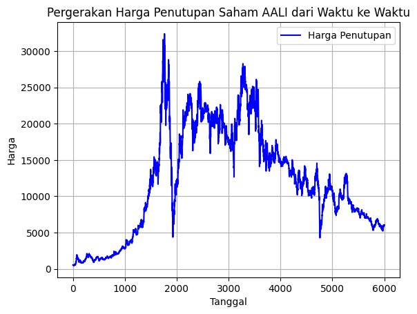

```python
plt.plot(df.index, df["AALI.JK.Close"], label='Harga Penutupan', color='blue')
plt.title(f'Pergerakan Harga Penutupan Saham {"AALI.JK.Close".replace(".JK.Close", "")} dari Waktu ke Waktu')
plt.xlabel('Tanggal')
plt.ylabel('Harga')
plt.grid(True)
plt.legend()
```

# Preprocessing

Data dibagi menjadi set latih (70%) dan set uji (30%) secara kronologis. Kolom `Date` kemudian ditetapkan sebagai indeks untuk kedua set data tersebut. Ukuran (jumlah baris dan kolom) dari data latih dan uji kemudian dicetak.

```python
# Membagi data menjadi train dan test berdasarkan tanggal
train_size = int(len(df) * 0.7)
train_data = df[:train_size]
test_data = df[train_size:]
train_data = train_data.set_index('Date')
test_data = test_data.set_index('Date')

# Print ukuran data train dan test
print(f"Ukuran data train: {train_data.shape}")
print(f"Ukuran data test: {test_data.shape}")
```

```
Ukuran data train: (4201, 1)
Ukuran data test: (1801, 1)
```

Normalisasi data dilakukan menggunakan `MinMaxScaler` dari scikit-learn untuk mengubah skala harga penutupan saham (`AALI.JK.Close`) ke rentang antara 0 dan 1. Proses `fit_transform` diterapkan pada data latih dan `transform` pada data uji.

```python
# Normalisasi data menggunakan MinMaxScaler
scaler = MinMaxScaler(feature_range=(0, 1))
# Pilih hanya kolom harga penutupan untuk normalisasi
train_prices_to_scale = train_data[['AALI.JK.Close']]
test_prices_to_scale = test_data[['AALI.JK.Close']]

train_data_scaled = scaler.fit_transform(train_prices_to_scale)
test_data_scaled = scaler.transform(test_prices_to_scale)
```

Dibuat instance `TimeseriesGenerator` untuk data latih dan data uji. Generator ini mengubah data deret waktu menjadi sekuens-sekuens yang sesuai untuk input model LSTM/CNN, dengan panjang sekuens (`look_back`) 30 dan ukuran batch 10.

```python
from tensorflow.keras.preprocessing.sequence import TimeseriesGenerator

look_back = 30

train_generator = TimeseriesGenerator(train_data_scaled, train_data_scaled,
                                      length        = look_back,
                                      sampling_rate = 1,
                                      stride        = 1,
                                      batch_size    = 10)

test_generator = TimeseriesGenerator(test_data_scaled, test_data_scaled,
                                      length        = look_back,
                                      sampling_rate = 1,
                                      stride        = 1,
                                      batch_size    = 10)
```

Didefinisikan beberapa callbacks Keras: `EarlyStopping` untuk menghentikan pelatihan jika tidak ada peningkatan pada `val_loss`, `ReduceLROnPlateau` untuk mengurangi learning rate jika pelatihan stagnan, dan `ModelCheckpoint` untuk menyimpan model dengan `val_loss` terbaik selama pelatihan.

```python
early_stopping = EarlyStopping(monitor='val_loss', patience=10, restore_best_weights=True)
lr_scheduler = ReduceLROnPlateau(monitor='val_loss', factor=0.2, patience=5, min_lr=0.00001)
# Tentukan path dan nama file untuk model terbaik
model_filepath = 'model_terbaik_val_loss.keras' # Atau .h5 untuk format lama

checkpoint = ModelCheckpoint(
    filepath=model_filepath,
    monitor='val_loss',      # Metrik yang dipantau
    save_best_only=True,     # Hanya simpan model jika 'val_loss' membaik
    mode='min',              # Mode 'min' karena kita ingin meminimalkan loss
    verbose=1                # Tampilkan pesan saat model disimpan
)
```

# CNN dengan LSTM

Didefinisikan arsitektur model hybrid CNN-LSTM menggunakan Keras Sequential API. Model terdiri dari lapisan `Conv1D`, `BatchNormalization`, `MaxPooling1D`, `Dropout`, diikuti oleh lapisan `LSTM`, `BatchNormalization`, `Dropout` lagi, dan diakhiri dengan lapisan `Dense` sebagai output.

```python
# Menggunakan variabel look_back yang sudah Anda definisikan sebelumnya
input_shape = (look_back, 1)

model_cnn_lstm = Sequential()

# Lapisan CNN
model_cnn_lstm.add(Conv1D(filters=32, kernel_size=3, activation='relu', input_shape=input_shape, padding='same', kernel_regularizer=regularizers.l2(0.001)))
model_cnn_lstm.add(BatchNormalization())
model_cnn_lstm.add(MaxPooling1D(pool_size=2))
model_cnn_lstm.add(Dropout(0.5))  # Dropout setelah max pooling

# Lapisan LSTM
model_cnn_lstm.add(LSTM(units=25, activation='relu', return_sequences=False, kernel_regularizer=regularizers.l2(0.001)))  # LSTM terakhir sebelum Dense
model_cnn_lstm.add(BatchNormalization())
model_cnn_lstm.add(Dropout(0.2))

# Lapisan Output
model_cnn_lstm.add(Dense(units=1))  # Output 1 unit untuk prediksi harga

# Menampilkan ringkasan model
model_cnn_lstm.summary()
```

```
Model: "sequential"
```

```
┏━━━━━━━━━━━━━━━━━━━━━━━━━━━━━━━━━┳━━━━━━━━━━━━━━━━━━━━━━━━┳━━━━━━━━━━━━━━━┓
┃ Layer (type)                    ┃ Output Shape           ┃       Param # ┃
┡━━━━━━━━━━━━━━━━━━━━━━━━━━━━━━━━━╇━━━━━━━━━━━━━━━━━━━━━━━━╇━━━━━━━━━━━━━━━┩
│ conv1d (Conv1D)                 │ (None, 30, 32)         │           128 │
├─────────────────────────────────┼────────────────────────┼───────────────┤
│ batch_normalization             │ (None, 30, 32)         │           128 │
│ (BatchNormalization)            │                        │               │
├─────────────────────────────────┼────────────────────────┼───────────────┤
│ max_pooling1d (MaxPooling1D)    │ (None, 15, 32)         │             0 │
├─────────────────────────────────┼────────────────────────┼───────────────┤
│ dropout (Dropout)               │ (None, 15, 32)         │             0 │
├─────────────────────────────────┼────────────────────────┼───────────────┤
│ lstm (LSTM)                     │ (None, 25)             │         5,800 │
├─────────────────────────────────┼────────────────────────┼───────────────┤
│ batch_normalization_1           │ (None, 25)             │           100 │
│ (BatchNormalization)            │                        │               │
├─────────────────────────────────┼────────────────────────┼───────────────┤
│ dropout_1 (Dropout)             │ (None, 25)             │             0 │
├─────────────────────────────────┼────────────────────────┼───────────────┤
│ dense (Dense)                   │ (None, 1)              │            26 │
└─────────────────────────────────┴────────────────────────┴───────────────┘
```

```
 Total params: 6,182 (24.15 KB)
```

```
 Trainable params: 6,068 (23.70 KB)
```

```
 Non-trainable params: 114 (456.00 B)
```

Model CNN-LSTM yang telah didefinisikan kemudian dikompilasi. Optimizer yang digunakan adalah `Adam` dengan `learning_rate` 0.0005, dan fungsi loss yang digunakan adalah '`mean_squared_error`'.

```python
optimizer = Adam(learning_rate=0.0005)
model_cnn_lstm.compile(optimizer=optimizer, loss='mean_squared_error')
```

```python
# Callbacks yang sudah didefinisikan sebelumnya digunakan
epochs = 30  # Jumlah epoch dapat disesuaikan sesuai kebutuhan
history_cnn_lstm = model_cnn_lstm.fit(
    train_generator,
    epochs=epochs,
    validation_data=test_generator,
    callbacks=[early_stopping, lr_scheduler, checkpoint],
    verbose=1
)
```

```
407/418 ━━━━━━━━━━━━━━━━━━━━ 0s 10ms/step - loss: 0.4903
Epoch 1: val_loss improved from inf to 0.06938, saving model to model_terbaik_val_loss.keras
418/418 ━━━━━━━━━━━━━━━━━━━━ 26s 14ms/step - loss: 0.4858 - val_loss: 0.0694 - learning_rate: 5.0000e-04
417/418 ━━━━━━━━━━━━━━━━━━━━ 0s 4ms/step - loss: 0.1538
Epoch 2: val_loss did not improve from 0.06938
418/418 ━━━━━━━━━━━━━━━━━━━━ 2s 5ms/step - loss: 0.1538 - val_loss: 0.1574 - learning_rate: 5.0000e-04
414/418 ━━━━━━━━━━━━━━━━━━━━ 0s 4ms/step - loss: 0.1246
Epoch 3: val_loss did not improve from 0.06938
418/418 ━━━━━━━━━━━━━━━━━━━━ 3s 7ms/step - loss: 0.1245 - val_loss: 0.1607 - learning_rate: 5.0000e-04
414/418 ━━━━━━━━━━━━━━━━━━━━ 0s 4ms/step - loss: 0.1053
Epoch 4: val_loss did not improve from 0.06938
418/418 ━━━━━━━━━━━━━━━━━━━━ 4s 5ms/step - loss: 0.1052 - val_loss: 0.2564 - learning_rate: 5.0000e-04
404/418 ━━━━━━━━━━━━━━━━━━━━ 0s 3ms/step - loss: 0.0912
Epoch 5: val_loss did not improve from 0.06938
418/418 ━━━━━━━━━━━━━━━━━━━━ 2s 5ms/step - loss: 0.0912 - val_loss: 0.0875 - learning_rate: 5.0000e-04
410/418 ━━━━━━━━━━━━━━━━━━━━ 0s 3ms/step - loss: 0.0928
Epoch 6: val_loss improved from 0.06938 to 0.04556, saving model to model_terbaik_val_loss.keras
418/418 ━━━━━━━━━━━━━━━━━━━━ 2s 5ms/step - loss: 0.0927 - val_loss: 0.0456 - learning_rate: 5.0000e-04
408/418 ━━━━━━━━━━━━━━━━━━━━ 0s 4ms/step - loss: 0.0854
Epoch 7: val_loss did not improve from 0.04556
418/418 ━━━━━━━━━━━━━━━━━━━━ 2s 5ms/step - loss: 0.0854 - val_loss: 0.0705 - learning_rate: 5.0000e-04
408/418 ━━━━━━━━━━━━━━━━━━━━ 0s 5ms/step - loss: 0.0836
Epoch 8: val_loss improved from 0.04556 to 0.02940, saving model to model_terbaik_val_loss.keras
418/418 ━━━━━━━━━━━━━━━━━━━━ 3s 7ms/step - loss: 0.0836 - val_loss: 0.0294 - learning_rate: 5.0000e-04
408/418 ━━━━━━━━━━━━━━━━━━━━ 0s 4ms/step - loss: 0.0854
Epoch 9: val_loss did not improve from 0.02940
418/418 ━━━━━━━━━━━━━━━━━━━━ 2s 5ms/step - loss: 0.0853 - val_loss: 0.0473 - learning_rate: 5.0000e-04
404/418 ━━━━━━━━━━━━━━━━━━━━ 0s 3ms/step - loss: 0.0795
Epoch 10: val_loss did not improve from 0.02940
418/418 ━━━━━━━━━━━━━━━━━━━━ 2s 5ms/step - loss: 0.0795 - val_loss: 0.1090 - learning_rate: 5.0000e-04
415/418 ━━━━━━━━━━━━━━━━━━━━ 0s 4ms/step - loss: 0.0751
Epoch 11: val_loss did not improve from 0.02940
418/418 ━━━━━━━━━━━━━━━━━━━━ 2s 5ms/step - loss: 0.0752 - val_loss: 0.1358 - learning_rate: 5.0000e-04
414/418 ━━━━━━━━━━━━━━━━━━━━ 0s 4ms/step - loss: 0.0761
Epoch 12: val_loss improved from 0.02940 to 0.02910, saving model to model_terbaik_val_loss.keras
418/418 ━━━━━━━━━━━━━━━━━━━━ 2s 5ms/step - loss: 0.0761 - val_loss: 0.0291 - learning_rate: 5.0000e-04
415/418 ━━━━━━━━━━━━━━━━━━━━ 0s 3ms/step - loss: 0.0755
Epoch 13: val_loss did not improve from 0.02910
418/418 ━━━━━━━━━━━━━━━━━━━━ 2s 5ms/step - loss: 0.0755 - val_loss: 0.0519 - learning_rate: 5.0000e-04
413/418 ━━━━━━━━━━━━━━━━━━━━ 0s 5ms/step - loss: 0.0779
```

[output cut: 20 more lines]

```
414/418 ━━━━━━━━━━━━━━━━━━━━ 0s 4ms/step - loss: 0.0723
Epoch 21: val_loss did not improve from 0.00330
418/418 ━━━━━━━━━━━━━━━━━━━━ 2s 5ms/step - loss: 0.0723 - val_loss: 0.0097 - learning_rate: 1.0000e-04
409/418 ━━━━━━━━━━━━━━━━━━━━ 0s 3ms/step - loss: 0.0732
Epoch 22: val_loss did not improve from 0.00330
418/418 ━━━━━━━━━━━━━━━━━━━━ 2s 5ms/step - loss: 0.0732 - val_loss: 0.0078 - learning_rate: 1.0000e-04
408/418 ━━━━━━━━━━━━━━━━━━━━ 0s 3ms/step - loss: 0.0644
Epoch 23: val_loss did not improve from 0.00330
418/418 ━━━━━━━━━━━━━━━━━━━━ 3s 5ms/step - loss: 0.0646 - val_loss: 0.0071 - learning_rate: 1.0000e-04
409/418 ━━━━━━━━━━━━━━━━━━━━ 0s 4ms/step - loss: 0.0755
Epoch 24: val_loss did not improve from 0.00330
418/418 ━━━━━━━━━━━━━━━━━━━━ 2s 5ms/step - loss: 0.0754 - val_loss: 0.0068 - learning_rate: 1.0000e-04
413/418 ━━━━━━━━━━━━━━━━━━━━ 0s 4ms/step - loss: 0.0652
Epoch 25: val_loss did not improve from 0.00330
418/418 ━━━━━━━━━━━━━━━━━━━━ 3s 7ms/step - loss: 0.0653 - val_loss: 0.0085 - learning_rate: 1.0000e-04
```

Setelah pelatihan, dimuat bobot model terbaik yang disimpan oleh `ModelCheckpoint` dari file '`model_terbaik_val_loss.kera`s' ke dalam `model_cnn_lstm`.

```python
model_cnn_lstm.load_weights('model_terbaik_val_loss.keras')
```

Fungsi `plot_training_predictions` dipanggil untuk memvisualisasikan perbandingan antara harga aktual dan prediksi model pada data latih, menggunakan model yang bobot terbaiknya telah dimuat

```
418/418 ━━━━━━━━━━━━━━━━━━━━ 2s 3ms/step
```

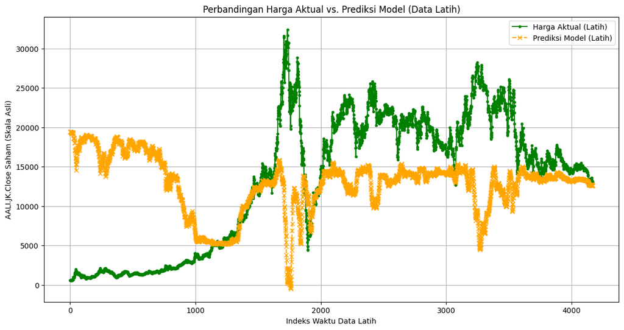

```python
plot_training_predictions(model_cnn_lstm, train_generator, scaler, target_column_name='AALI.JK.Close')
```

Fungsi `plot_test_predictions` dipanggil untuk memvisualisasikan perbandingan antara harga aktual dan prediksi model pada data uji.

```
178/178 ━━━━━━━━━━━━━━━━━━━━ 0s 2ms/step
```

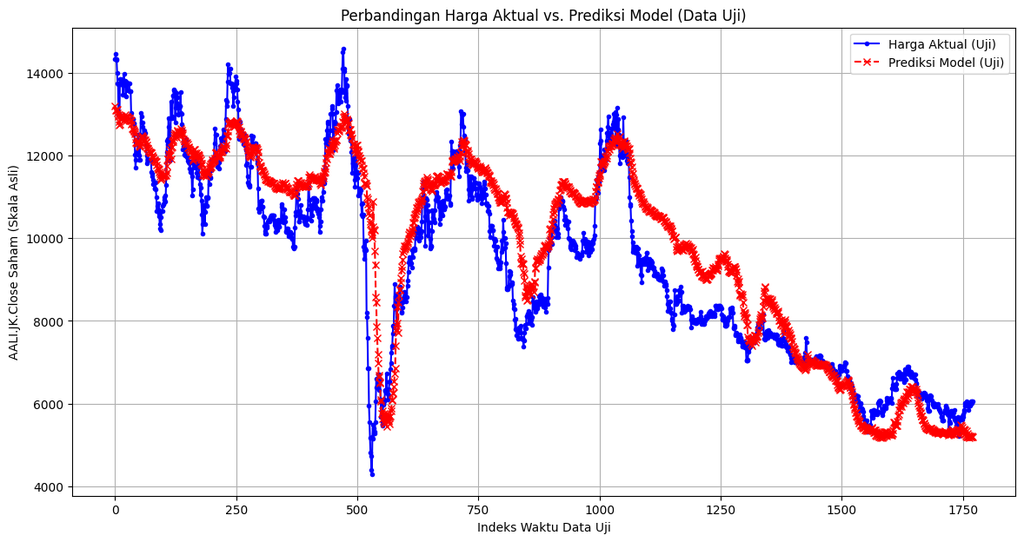

```python
plot_test_predictions(model_cnn_lstm, test_generator, scaler, target_column_name='AALI.JK.Close')
```

Dilakukan prediksi pada data uji, melakukan inverse transform pada nilai prediksi dan aktual ke skala harga asli, kemudian menghitung dan mencetak metrik Root Mean Squared Error (RMSE) dan Mean Absolute Error (MAE).

```python
y_pred_scaled = model_cnn_lstm.predict(test_generator)
y_test_scaled_list = []
for i in range(len(test_generator)):
    _, y_batch = test_generator[i]
    y_test_scaled_list.extend(y_batch)

y_test_scaled = np.array(y_test_scaled_list)

# Penyesuaian panjang jika diperlukan
num_test_predictions = len(y_pred_scaled)
y_test_scaled = y_test_scaled[:num_test_predictions]
if y_pred_scaled.ndim == 3:  # Jika output LSTM dengan return_sequences=True
    y_pred_scaled = y_pred_scaled[:, -1, :]
if y_pred_scaled.ndim == 1:
    y_pred_scaled = y_pred_scaled.reshape(-1, 1)
if y_test_scaled.ndim == 1:
    y_test_scaled = y_test_scaled.reshape(-1, 1)

y_pred_original = scaler.inverse_transform(y_pred_scaled)
y_test_original = scaler.inverse_transform(y_test_scaled)

from sklearn.metrics import mean_squared_error, mean_absolute_error
import numpy as np

rmse = np.sqrt(mean_squared_error(y_test_original, y_pred_original))
print(f"Test RMSE (Original Scale): {rmse}")

mae = mean_absolute_error(y_test_original, y_pred_original)
print(f"Test MAE (Original Scale): {mae}")
```

```
178/178 ━━━━━━━━━━━━━━━━━━━━ 0s 2ms/step
Test RMSE (Original Scale): 1003.7234457648071
Test MAE (Original Scale): 768.0581060201687
```

# Hyperparameter Tuning

Fungsi `build_model_toner(hp)` didefinisikan untuk KerasTuner. Fungsi ini membangun arsitektur model CNN-LSTM yang sama seperti model dasar, namun beberapa hyperparameter (seperti jumlah filter CNN, ukuran kernel, dropout rates, unit LSTM, dan learning rate) didefinisikan sebagai variabel yang akan dioptimalkan oleh KerasTuner

```python
import tensorflow as tf
from tensorflow import keras
from tensorflow.keras.models import Sequential
from tensorflow.keras.layers import Conv1D, MaxPooling1D, LSTM, Dense, Dropout, BatchNormalization
from tensorflow.keras.optimizers import Adam
from tensorflow.keras import regularizers
import keras_tuner as kt

look_back = 30

def build_model_tuner(hp):
    input_shape_dynamic = (look_back, 1)  # Pastikan look_back dapat diakses

    model = Sequential()

    # --- Lapisan CNN ---
    hp_conv_filters = hp.Int('conv_filters', min_value=24, max_value=36, step=4)
    hp_kernel_size_conv = hp.Choice('kernel_size_conv', values=[2, 3]) # Pilihan kernel size
    hp_l2_conv = hp.Float('l2_conv', min_value=1e-4, max_value=1e-2, sampling='log') # Tuning L2 untuk Conv

    model.add(Conv1D(filters=hp_conv_filters,
                     kernel_size=hp_kernel_size_conv,
                     activation='relu',
                     input_shape=input_shape_dynamic,
                     padding='same',
                     kernel_regularizer=regularizers.l2(hp_l2_conv)))
    model.add(BatchNormalization())
    model.add(MaxPooling1D(pool_size=2))

    hp_dropout_conv = hp.Float('dropout_conv', min_value=0.4, max_value=0.6, step=0.1) # Sekitar 0.5
    model.add(Dropout(hp_dropout_conv))

    # --- Lapisan LSTM ---
    hp_lstm_units = hp.Int('lstm_units', min_value=17, max_value=33, step=4) # Rentang 16, 24, 32 (sekitar 25)
    hp_l2_lstm = hp.Float('l2_lstm', min_value=1e-4, max_value=1e-2, sampling='log') # Tuning L2 untuk LSTM

    model.add(LSTM(units=hp_lstm_units,
                   activation='relu', # Sesuai model dasar Anda
                   return_sequences=False,
                   kernel_regularizer=regularizers.l2(hp_l2_lstm)))
    model.add(BatchNormalization())

    hp_dropout_lstm = hp.Float('dropout_lstm', min_value=0.1, max_value=0.4, step=0.1) # Sekitar 0.2
    model.add(Dropout(hp_dropout_lstm))

    # --- Lapisan Output ---
    model.add(Dense(units=1))

    # Hyperparameter untuk Learning Rate
    hp_learning_rate = hp.Choice('learning_rate', values=[1e-4, 5e-4, 1e-3]) # Termasuk 1e-4 dan 5e-4

    model.compile(optimizer=Adam(learning_rate=hp_learning_rate),
                  loss='mean_squared_error')
    return model
```

Didefinisikan sebuah tuner_model dengan strategi `RandomSearch` dari KerasTuner diinisialisasi. Tuner ini akan menggunakan fungsi `build_model` untuk mencoba berbagai kombinasi hyperparameter dengan tujuan meminimalkan `val_loss`. Ringkasan ruang pencarian hyperparameter kemudian ditampilkan.

```python
tuner_model = kt.RandomSearch(
    build_model_tuner,
    objective='val_loss', # Metrik yang ingin dioptimalkan (diminimalkan)
    max_trials=20, # Jumlah total kombinasi parameter yang akan dicoba
    executions_per_trial=1, # Berapa kali setiap kombinasi dilatih (untuk stabilitas, bisa >1)
    directory='my_kt_project', # Direktori untuk menyimpan hasil tuning
    project_name='stock_price_tuning' # Nama proyek
)

# Menampilkan ringkasan dari ruang pencarian hyperparameter
tuner_model.search_space_summary()
```

```
Search space summary
Default search space size: 8
conv_filters (Int)
{'default': None, 'conditions': [], 'min_value': 24, 'max_value': 36, 'step': 4, 'sampling': 'linear'}
kernel_size_conv (Choice)
{'default': 2, 'conditions': [], 'values': [2, 3], 'ordered': True}
l2_conv (Float)
{'default': 0.0001, 'conditions': [], 'min_value': 0.0001, 'max_value': 0.01, 'step': None, 'sampling': 'log'}
dropout_conv (Float)
{'default': 0.4, 'conditions': [], 'min_value': 0.4, 'max_value': 0.6, 'step': 0.1, 'sampling': 'linear'}
lstm_units (Int)
{'default': None, 'conditions': [], 'min_value': 17, 'max_value': 33, 'step': 4, 'sampling': 'linear'}
l2_lstm (Float)
{'default': 0.0001, 'conditions': [], 'min_value': 0.0001, 'max_value': 0.01, 'step': None, 'sampling': 'log'}
dropout_lstm (Float)
{'default': 0.1, 'conditions': [], 'min_value': 0.1, 'max_value': 0.4, 'step': 0.1, 'sampling': 'linear'}
learning_rate (Choice)
{'default': 0.0001, 'conditions': [], 'values': [0.0001, 0.0005, 0.001], 'ordered': True}
```

Proses pencarian hyperparameter dijalankan menggunakan metode tuner.search(). Proses ini akan melatih berbagai konfigurasi model pada train_generator, divalidasi dengan test_generator, dan menggunakan callback early_stopping. Setiap trial dilatih hingga 100 epoch.

```python
epochs_per_trial = 100
print("Memulai pencarian hyperparameter dengan rentang yang diperluas...")
tuner_model.search(
    train_generator,
    epochs=epochs_per_trial,
    validation_data=test_generator,
    callbacks=[early_stopping],  # EarlyStopping digunakan saat pencarian
    verbose=1
)
```

```
Trial 20 Complete [00h 01m 45s]
val_loss: 0.006267347373068333

Best val_loss So Far: 0.0011797752231359482
Total elapsed time: 00h 24m 06s
```

Setelah pencarian selesai, hyperparameter terbaik (best_hps) diambil dari tuner. Model kemudian dibangun kembali (best_model) menggunakan konfigurasi hyperparameter terbaik ini.

```python
best_hps = tuner_model.get_best_hyperparameters(num_trials=1)[0]
print("--- Hyperparameter Terbaik (Format Dictionary) ---")
print(best_hps.values)
best_model = tuner_model.hypermodel.build(best_hps)
best_model.summary()
```

```
--- Hyperparameter Terbaik (Format Dictionary) ---
{'conv_filters': 24, 'kernel_size_conv': 2, 'l2_conv': 0.00025414194281719714, 'dropout_conv': 0.5, 'lstm_units': 25, 'l2_lstm': 0.0005095016426245528, 'dropout_lstm': 0.1, 'learning_rate': 0.0005}
```

```
Model: "sequential_1"
```

```
┏━━━━━━━━━━━━━━━━━━━━━━━━━━━━━━━━━┳━━━━━━━━━━━━━━━━━━━━━━━━┳━━━━━━━━━━━━━━━┓
┃ Layer (type)                    ┃ Output Shape           ┃       Param # ┃
┡━━━━━━━━━━━━━━━━━━━━━━━━━━━━━━━━━╇━━━━━━━━━━━━━━━━━━━━━━━━╇━━━━━━━━━━━━━━━┩
│ conv1d_1 (Conv1D)               │ (None, 30, 24)         │            72 │
├─────────────────────────────────┼────────────────────────┼───────────────┤
│ batch_normalization_2           │ (None, 30, 24)         │            96 │
│ (BatchNormalization)            │                        │               │
├─────────────────────────────────┼────────────────────────┼───────────────┤
│ max_pooling1d_1 (MaxPooling1D)  │ (None, 15, 24)         │             0 │
├─────────────────────────────────┼────────────────────────┼───────────────┤
│ dropout_2 (Dropout)             │ (None, 15, 24)         │             0 │
├─────────────────────────────────┼────────────────────────┼───────────────┤
│ lstm_1 (LSTM)                   │ (None, 25)             │         5,000 │
├─────────────────────────────────┼────────────────────────┼───────────────┤
│ batch_normalization_3           │ (None, 25)             │           100 │
│ (BatchNormalization)            │                        │               │
├─────────────────────────────────┼────────────────────────┼───────────────┤
│ dropout_3 (Dropout)             │ (None, 25)             │             0 │
├─────────────────────────────────┼────────────────────────┼───────────────┤
│ dense_1 (Dense)                 │ (None, 1)              │            26 │
└─────────────────────────────────┴────────────────────────┴───────────────┘
```

```
 Total params: 5,294 (20.68 KB)
```

```
 Trainable params: 5,196 (20.30 KB)
```

```
 Non-trainable params: 98 (392.00 B)
```

Dibuat nama file dinamis `(final_model_filepath)`untuk menyimpan model terbaik hasil tuning berdasarkan hyperparameter yang ditemukan. Sebuah callback `ModelCheckpoint` baru (`final_checkpoint`) juga didefinisikan untuk menyimpan model hanya jika `val_loss` membaik selama pelatihan ulang.

```python
try:
    # Mengambil nilai hyperparameter terbaik
    lstm_units_val = best_hps.get('lstm_units')
    conv_filters_val = best_hps.get('conv_filters')
    kernel_size_val = best_hps.get('kernel_size_conv')
    dropout_conv_val = best_hps.get('dropout_conv')
    dropout_lstm_val = best_hps.get('dropout_lstm')
    learning_rate_val = best_hps.get('learning_rate')

    # Membuat deskripsi model untuk nama file
    final_model_description = (
        f"lstm{lstm_units_val}"
        f"_conv{conv_filters_val}"
        f"_ks{kernel_size_val}"
        f"_dropconv{str(round(dropout_conv_val, 2)).replace('.', '')}"
        f"_droplstm{str(round(dropout_lstm_val, 2)).replace('.', '')}"
        f"_lr{str(learning_rate_val).replace('0.', '').replace('.', '')}" # Menghilangkan '0.' dan '.'
    )
    final_model_filepath = f"model_final_terbaik_{final_model_description}.keras"

    print(f"Nama file model terbaik disimpan sebagai: {final_model_filepath}")

    final_checkpoint = ModelCheckpoint(
        filepath=final_model_filepath,
        monitor='val_loss',
        save_best_only=True,
        mode='min',
        verbose=1
    )
except Exception as e:
    print(f"Terjadi kesalahan saat membuat nama file atau ModelCheckpoint: {e}")
    print("Pastikan semua nama hyperparameter dalam best_hps.get() sudah benar dan sesuai dengan definisi di build_model_expanded.")
    # Anda bisa set final_checkpoint ke None atau path default jika terjadi error
    final_checkpoint = None
```

```
Nama file model terbaik disimpan sebagai: model_final_terbaik_lstm25_conv24_ks2_dropconv05_droplstm01_lr0005.keras
```

Model dengan hyperparameter terbaik (best_model) dilatih ulang untuk jumlah epoch yang lebih banyak (`final_epochs` = 150). Callbacks `final_checkpoint` (untuk menyimpan model terbaik dari pelatihan ulang ini) digunakan.

```python
# Latih model terbaik untuk jumlah epoch yang lebih optimal
# Pastikan early_stopping dan lr_scheduler sudah terdefinisi
final_epochs = 150 # Misalnya, sesuaikan dengan kebutuhan
history_final_model = best_model.fit(
    train_generator,
    epochs=final_epochs,
    validation_data=test_generator,
    callbacks=[final_checkpoint] # lr_scheduler bisa dipakai lagi
)
```

```
416/418 ━━━━━━━━━━━━━━━━━━━━ 0s 10ms/step - loss: 0.5369
Epoch 1: val_loss improved from inf to 0.05853, saving model to model_final_terbaik_lstm25_conv24_ks2_dropconv05_droplstm01_lr0005.keras
418/418 ━━━━━━━━━━━━━━━━━━━━ 12s 15ms/step - loss: 0.5354 - val_loss: 0.0585
414/418 ━━━━━━━━━━━━━━━━━━━━ 0s 4ms/step - loss: 0.1640
Epoch 2: val_loss did not improve from 0.05853
418/418 ━━━━━━━━━━━━━━━━━━━━ 2s 5ms/step - loss: 0.1639 - val_loss: 16.0733
411/418 ━━━━━━━━━━━━━━━━━━━━ 0s 5ms/step - loss: 0.1231
Epoch 3: val_loss did not improve from 0.05853
418/418 ━━━━━━━━━━━━━━━━━━━━ 3s 6ms/step - loss: 0.1231 - val_loss: 20.1078
414/418 ━━━━━━━━━━━━━━━━━━━━ 0s 4ms/step - loss: 0.1092
Epoch 4: val_loss did not improve from 0.05853
418/418 ━━━━━━━━━━━━━━━━━━━━ 2s 5ms/step - loss: 0.1092 - val_loss: 3.2019
409/418 ━━━━━━━━━━━━━━━━━━━━ 0s 4ms/step - loss: 0.0924
Epoch 5: val_loss did not improve from 0.05853
418/418 ━━━━━━━━━━━━━━━━━━━━ 2s 5ms/step - loss: 0.0924 - val_loss: 2.4039
416/418 ━━━━━━━━━━━━━━━━━━━━ 0s 4ms/step - loss: 0.0786
Epoch 6: val_loss did not improve from 0.05853
418/418 ━━━━━━━━━━━━━━━━━━━━ 2s 5ms/step - loss: 0.0786 - val_loss: 4.5342
415/418 ━━━━━━━━━━━━━━━━━━━━ 0s 3ms/step - loss: 0.0790
Epoch 7: val_loss did not improve from 0.05853
418/418 ━━━━━━━━━━━━━━━━━━━━ 2s 5ms/step - loss: 0.0790 - val_loss: 2.9624
414/418 ━━━━━━━━━━━━━━━━━━━━ 0s 4ms/step - loss: 0.0791
Epoch 8: val_loss did not improve from 0.05853
418/418 ━━━━━━━━━━━━━━━━━━━━ 2s 5ms/step - loss: 0.0791 - val_loss: 2.1929
405/418 ━━━━━━━━━━━━━━━━━━━━ 0s 5ms/step - loss: 0.0789
Epoch 9: val_loss did not improve from 0.05853
418/418 ━━━━━━━━━━━━━━━━━━━━ 3s 6ms/step - loss: 0.0789 - val_loss: 1.0871
417/418 ━━━━━━━━━━━━━━━━━━━━ 0s 4ms/step - loss: 0.0778
Epoch 10: val_loss did not improve from 0.05853
418/418 ━━━━━━━━━━━━━━━━━━━━ 2s 5ms/step - loss: 0.0778 - val_loss: 0.1256
417/418 ━━━━━━━━━━━━━━━━━━━━ 0s 3ms/step - loss: 0.0802
Epoch 11: val_loss did not improve from 0.05853
418/418 ━━━━━━━━━━━━━━━━━━━━ 3s 5ms/step - loss: 0.0802 - val_loss: 0.2702
416/418 ━━━━━━━━━━━━━━━━━━━━ 0s 4ms/step - loss: 0.0771
Epoch 12: val_loss did not improve from 0.05853
418/418 ━━━━━━━━━━━━━━━━━━━━ 2s 5ms/step - loss: 0.0771 - val_loss: 1.3529
416/418 ━━━━━━━━━━━━━━━━━━━━ 0s 4ms/step - loss: 0.0777
Epoch 13: val_loss did not improve from 0.05853
418/418 ━━━━━━━━━━━━━━━━━━━━ 2s 5ms/step - loss: 0.0777 - val_loss: 0.8056
409/418 ━━━━━━━━━━━━━━━━━━━━ 0s 5ms/step - loss: 0.0704
```

[output cut: 395 more lines]

```
409/418 ━━━━━━━━━━━━━━━━━━━━ 0s 4ms/step - loss: 0.0722
Epoch 146: val_loss did not improve from 0.00117
418/418 ━━━━━━━━━━━━━━━━━━━━ 3s 6ms/step - loss: 0.0722 - val_loss: 0.0147
410/418 ━━━━━━━━━━━━━━━━━━━━ 0s 5ms/step - loss: 0.0713
Epoch 147: val_loss did not improve from 0.00117
418/418 ━━━━━━━━━━━━━━━━━━━━ 3s 6ms/step - loss: 0.0713 - val_loss: 0.0067
411/418 ━━━━━━━━━━━━━━━━━━━━ 0s 4ms/step - loss: 0.0731
Epoch 148: val_loss did not improve from 0.00117
418/418 ━━━━━━━━━━━━━━━━━━━━ 2s 5ms/step - loss: 0.0731 - val_loss: 0.0042
417/418 ━━━━━━━━━━━━━━━━━━━━ 0s 4ms/step - loss: 0.0688
Epoch 149: val_loss did not improve from 0.00117
418/418 ━━━━━━━━━━━━━━━━━━━━ 2s 5ms/step - loss: 0.0688 - val_loss: 0.0134
415/418 ━━━━━━━━━━━━━━━━━━━━ 0s 4ms/step - loss: 0.0692
Epoch 150: val_loss did not improve from 0.00117
418/418 ━━━━━━━━━━━━━━━━━━━━ 2s 5ms/step - loss: 0.0692 - val_loss: 0.0045
```

Model yang telah dilatih ulang dengan hyperparameter terbaik (`best_model`) ditetapkan ke variabel `model_to_plot` untuk digunakan dalam visualisasi prediksi.

```python
best_model.load_weights(final_model_filepath)
model_to_plot = best_model
model_to_plot.summary()
```

```
Model: "sequential_1"
```

```
┏━━━━━━━━━━━━━━━━━━━━━━━━━━━━━━━━━┳━━━━━━━━━━━━━━━━━━━━━━━━┳━━━━━━━━━━━━━━━┓
┃ Layer (type)                    ┃ Output Shape           ┃       Param # ┃
┡━━━━━━━━━━━━━━━━━━━━━━━━━━━━━━━━━╇━━━━━━━━━━━━━━━━━━━━━━━━╇━━━━━━━━━━━━━━━┩
│ conv1d_1 (Conv1D)               │ (None, 30, 24)         │            72 │
├─────────────────────────────────┼────────────────────────┼───────────────┤
│ batch_normalization_2           │ (None, 30, 24)         │            96 │
│ (BatchNormalization)            │                        │               │
├─────────────────────────────────┼────────────────────────┼───────────────┤
│ max_pooling1d_1 (MaxPooling1D)  │ (None, 15, 24)         │             0 │
├─────────────────────────────────┼────────────────────────┼───────────────┤
│ dropout_2 (Dropout)             │ (None, 15, 24)         │             0 │
├─────────────────────────────────┼────────────────────────┼───────────────┤
│ lstm_1 (LSTM)                   │ (None, 25)             │         5,000 │
├─────────────────────────────────┼────────────────────────┼───────────────┤
│ batch_normalization_3           │ (None, 25)             │           100 │
│ (BatchNormalization)            │                        │               │
├─────────────────────────────────┼────────────────────────┼───────────────┤
│ dropout_3 (Dropout)             │ (None, 25)             │             0 │
├─────────────────────────────────┼────────────────────────┼───────────────┤
│ dense_1 (Dense)                 │ (None, 1)              │            26 │
└─────────────────────────────────┴────────────────────────┴───────────────┘
```

```
 Total params: 15,688 (61.29 KB)
```

```
 Trainable params: 5,196 (20.30 KB)
```

```
 Non-trainable params: 98 (392.00 B)
```

```
 Optimizer params: 10,394 (40.61 KB)
```

Fungsi `plot_training_predictions` dipanggil untuk memvisualisasikan prediksi dari model hasil tuning pada data latih

```
418/418 ━━━━━━━━━━━━━━━━━━━━ 3s 5ms/step
```

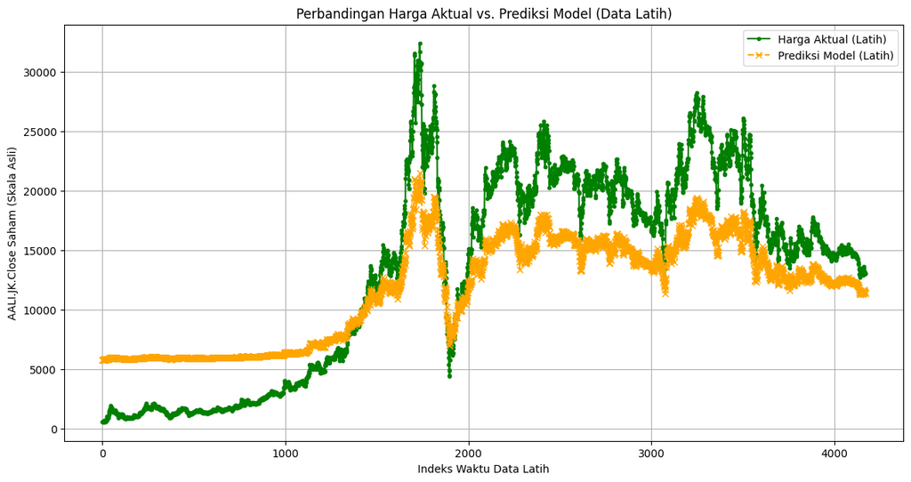

```python
plot_training_predictions(model_to_plot, train_generator, scaler, target_column_name='AALI.JK.Close')
```

Fungsi `plot_test_predictions` dipanggil untuk memvisualisasikan prediksi dari model hasil tuning pada data uji

```
178/178 ━━━━━━━━━━━━━━━━━━━━ 0s 2ms/step
```

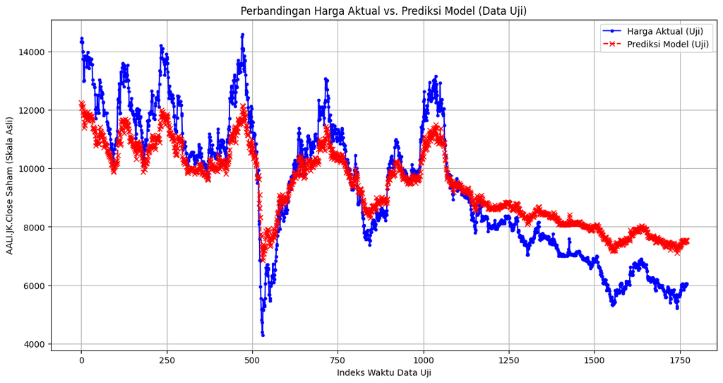

```python
plot_test_predictions(model_to_plot, test_generator, scaler, target_column_name='AALI.JK.Close')
```

Dipanggil fungsi `plot_training_history` untuk memvisualisasikan kurva loss dari pelatihan model final (hasil tuning)

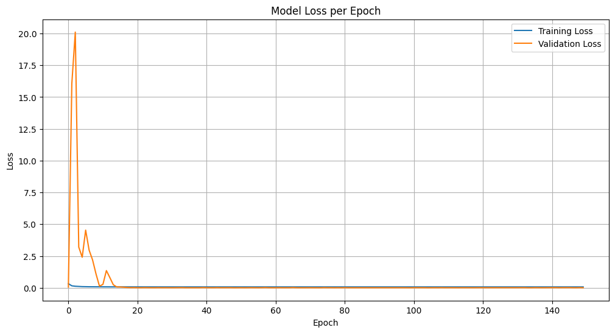

```python
plot_training_history(history_final_model, metrics_to_plot=['loss'])
```

Prediksi dibuat menggunakan model hasil tuning pada data uji, kemudian di-inverse transform ke skala harga asli. Metrik RMSE dan MAE kemudian dihitung dan dicetak untuk mengevaluasi kinerja model yang telah dioptimalkan.

```python
y_pred_scaled = model_to_plot.predict(test_generator)
y_test_scaled_list = []
for i in range(len(test_generator)):
  _, y_batch = test_generator[i]
  y_test_scaled_list.extend(y_batch)

y_test_scaled = np.array(y_test_scaled_list)


num_test_predictions = len(y_pred_scaled)
y_test_scaled = y_test_scaled[:num_test_predictions]
if y_pred_scaled.ndim == 3:
    y_pred_scaled = y_pred_scaled[:, -1, :]
if y_pred_scaled.ndim == 1:
    y_pred_scaled = y_pred_scaled.reshape(-1,1)
if y_test_scaled.ndim == 1:
    y_test_scaled = y_test_scaled.reshape(-1,1)


y_pred_original = scaler.inverse_transform(y_pred_scaled)
y_test_original = scaler.inverse_transform(y_test_scaled)

from sklearn.metrics import mean_squared_error
import numpy as np
rmse = np.sqrt(mean_squared_error(y_test_original, y_pred_original))
print(f"Test RMSE (Original Scale): {rmse}")
# Anda juga bisa menghitung MAE
from sklearn.metrics import mean_absolute_error
mae = mean_absolute_error(y_test_original, y_pred_original)
print(f"Test MAE (Original Scale): {mae}")
```

```
178/178 ━━━━━━━━━━━━━━━━━━━━ 0s 2ms/step
Test RMSE (Original Scale): 1081.8967194776776
Test MAE (Original Scale): 933.1244058463615
```